# Biostat 212a Homework 1

## 5

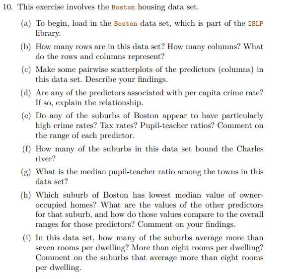

(a) Done!

(b)There are 506 rows and 13 columns. Rows represent suburbs or towns in the Boston area. Each column represents a predictor (feature) or response variable (e.g., crime rate, tax rate, median value of homes).

(c)

(d)

(e)

## 6 ISL Exercise 3.7.3 (20% pts)

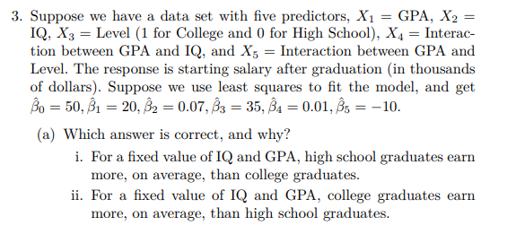

## 7

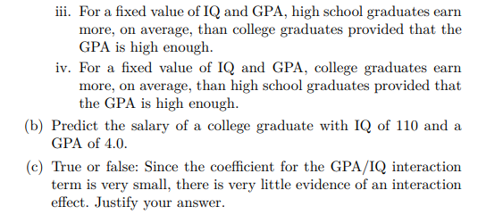

## 8 ISL Exercise 3.7.15 (20% pts)

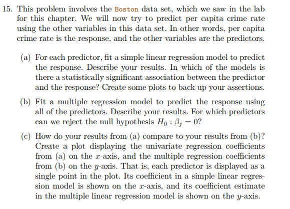

## 9

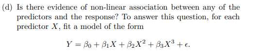

## 10 Bonus question (20% pts)

For multiple linear regression, show that $R^2$ is equal to the correlation between the response vector $\mathbf{y} = (y_1, \ldots, y_n)^T$ and the fitted values $\hat{\mathbf{y}} = (\hat y_1, \ldots, \hat y_n)^T$. That is
$$R^2 = 1 - \frac{\text{RSS}}{\text{TSS}} = [\operatorname{Cor}(\mathbf{y}, \hat{\mathbf{y}})]^2.$$